# Rest-Mex 2025 · texto con textrecipes

Del texto a la matriz, dentro de la receta

En `02_modelo.qmd` las palabras se volvieron columnas **a mano**: `tokenizar()`, `elegir_vocabulario()` y `con_palabras()`. Aquí se hace lo mismo con **textrecipes**, la extensión de `recipes` para texto. La ventaja no es escribir menos: es que el vocabulario se aprende **dentro de la receta**, así que en validación cruzada se vuelve a aprender en cada pliegue y nunca ve los datos con que se califica.

Paquetes extra para este notebook: `install.packages(c("textrecipes", "glmnet", "stopwords", "SnowballC"))`.

> **Tarda:** unos 20 minutos en una laptop, porque tokeniza 26 mil reseñas en cada pliegue y para cada tamaño de vocabulario (3 recetas × 3 tamaños × 5 pliegues). Para probar rápido, baja `slice_sample(n = 40000)` a 10 mil.

```r
library(tidyverse)
library(tidymodels)
library(textrecipes)
library(here)
```

# 1. Una receta de texto, paso a paso

Dos reseñas inventadas para ver qué hace cada paso. `step_untokenize()` vuelve a pegar los tokens para poder leerlos.

```r
ejemplo <- tibble(resena = c(
  "La comida NO estaba buena, el servicio muy lento.",
  "Excelente comida y muy buen servicio, lo recomiendo ampliamente."
))

ver <- function(receta) {
  receta |> step_untokenize(resena) |> prep() |> bake(new_data = NULL)
}

base <- recipe(~ resena, data = ejemplo) |> step_tokenize(resena)

ver(base)                                                       # minúsculas, sin puntuación
```

```
# A tibble: 2 × 1
  resena
  <fct>
1 la comida no estaba buena el servicio muy lento
2 excelente comida y muy buen servicio lo recomiendo ampliamente
```

```r
ver(base |> step_stopwords(resena, language = "es"))            # sin palabras vacías
```

```
# A tibble: 2 × 1
  resena
  <fct>
1 comida buena servicio lento
2 excelente comida buen servicio recomiendo ampliamente
```

```r
ver(base |> step_stopwords(resena, language = "es") |>
      step_stem(resena, options = list(language = "spanish")))  # raíces
```

```
# A tibble: 2 × 1
  resena
  <fct>
1 com buen servici lent
2 excelent com buen servici recom ampli
```

## La trampa de las *stopwords*

La primera reseña era una queja y, sin palabras vacías, dice **«comida buena servicio lento»**. La lista de Snowball en español trae 308 palabras, y entre ellas están justo las que cargan el sentimiento:

```r
c("no", "muy", "sin", "nada", "ni", "poco", "mucho") |>
  set_names() |>
  map_lgl(\(p) p %in% stopwords::stopwords("es"))
```

```
   no   muy   sin  nada    ni  poco mucho
 TRUE  TRUE  TRUE  TRUE  TRUE  TRUE  TRUE
```

Para clasificar temas, quitarlas ayuda. Para clasificar **sentimiento**, hay que probarlo antes de creerlo. Eso se hace abajo.

## n-gramas: el orden importa un poco

```r
ver(base |> step_ngram(resena, num_tokens = 2, min_num_tokens = 1))
```

```
# A tibble: 2 × 1
  resena
  <fct>
1 la comida no estaba buena el servicio muy lento la_comida comida_no no_estaba…
2 excelente comida y muy buen servicio lo recomiendo ampliamente excelente_comi…
```

Con bigramas, `no_estaba` y `muy_lento` son columnas propias.

## De tokens a números

```r
base |> step_tf(resena) |> prep() |> bake(new_data = NULL) |> select(1:6)
```

```
# A tibble: 2 × 6
  tf_resena_ampliamente tf_resena_buen tf_resena_buena tf_resena_comida
                  <int>          <int>           <int>            <int>
1                     0              0               1                1
2                     1              1               0                1
# ℹ 2 more variables: tf_resena_el <int>, tf_resena_estaba <int>
```

```r
base |> step_tfidf(resena) |> prep() |> bake(new_data = NULL) |> select(1:6)
```

```
# A tibble: 2 × 6
  tfidf_resena_ampliamente tfidf_resena_buen tfidf_resena_buena
                     <dbl>             <dbl>              <dbl>
1                    0                 0                  0.122
2                    0.122             0.122              0
# ℹ 3 more variables: tfidf_resena_comida <dbl>, tfidf_resena_el <dbl>,
#   tfidf_resena_estaba <dbl>
```

`step_tf()` cuenta; `step_tfidf()` además castiga las palabras que salen en todos los documentos. Con miles de reseñas, `comida` pesa poco y `pésimo` mucho.

# 2. Los datos

La misma muestra y la misma partición que `02_modelo.qmd`, para que la comparación sea justa. Ahora el texto entra crudo: lo procesa la receta.

```r
set.seed(2025)
datos <- read_rds(here("data", "processed", "resenas.rds")) |>
  slice_sample(n = 40000) |>
  select(id, satisfecho, tipo, n_palabras, resena)

particion     <- initial_split(datos, prop = 0.8, strata = satisfecho)
entrenamiento <- training(particion)
prueba        <- testing(particion)

set.seed(2025)
pliegues <- vfold_cv(entrenamiento, v = 5, strata = satisfecho)
```

# 3. Tres recetas

Las tres terminan en tf-idf y dejan que la validación cruzada decida cuántas palabras guardar (`max_tokens = tune()`). Cambia lo de en medio:

```r
inicio <- recipe(satisfecho ~ resena + tipo, data = entrenamiento) |>
  step_dummy(tipo) |>
  step_tokenize(resena)

final_tfidf <- function(receta) {
  receta |>
    step_tokenfilter(resena, max_tokens = tune()) |>
    step_tfidf(resena)
}

recetas <- list(
  palabras        = inicio |> final_tfidf(),
  sin_stopwords   = inicio |> step_stopwords(resena, language = "es") |> final_tfidf(),
  palabras_y_pares = inicio |> step_ngram(resena, num_tokens = 2, min_num_tokens = 1) |>
                      final_tfidf()
)
```

# 4. El modelo: regresión logística con lasso

Miles de columnas, casi todas en cero. Dos decisiones para eso:

- **Lasso** (`mixture = 1`): castiga los coeficientes y manda a cero los de las palabras que no aportan. `penalty` dice qué tan fuerte, y también se afina.
- **Matriz dispersa**: el *blueprint* le pasa a glmnet una matriz que solo guarda los valores distintos de cero. Sin eso, 32 mil reseñas × 2 mil palabras son medio giga de ceros.

```r
lasso <- logistic_reg(penalty = tune(), mixture = 1) |>
  set_engine("glmnet")

dispersa <- hardhat::default_recipe_blueprint(composition = "dgCMatrix")

rejilla <- grid_regular(
  penalty(range = c(-4, -1)),
  max_tokens(range = c(500, 2000)),
  levels = c(penalty = 6, max_tokens = 3)
)
rejilla |> count(max_tokens)
```

```
# A tibble: 3 × 2
  max_tokens     n
       <int> <int>
1        500     6
2       1250     6
3       2000     6
```

# 5. Afinar: 3 recetas × 18 combinaciones × 5 pliegues

```r
metricas <- metric_set(roc_auc, pr_auc, kap, sens, spec)

afinados <- recetas |>
  map(\(r) workflow() |> add_recipe(r, blueprint = dispersa) |> add_model(lasso)) |>
  map(\(wf) tune_grid(wf, resamples = pliegues, grid = rejilla, metrics = metricas))
```

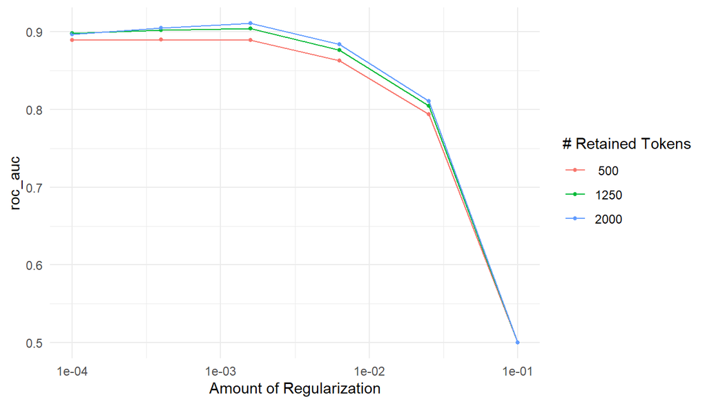

```r
autoplot(afinados |> pluck("palabras"), metric = "roc_auc") +
  theme_minimal()
```

Con poca penalización el AUC baja un poco: el lasso se queda con casi todo, incluido el ruido. Con mucha se desploma: en `penalty = 0.1` borra todas las palabras y el AUC cae a 0.5, el del modelo nulo. El punto alto está en medio, alrededor de 0.002.

## La mejor combinación de cada receta

```r
mejores <- afinados |>
  imap(\(a, nombre) show_best(a, metric = "roc_auc", n = 1) |> mutate(receta = nombre)) |>
  list_rbind() |>
  select(receta, max_tokens, penalty, roc_auc = mean, std_err)

mejores |> arrange(desc(roc_auc)) |> knitr::kable(digits = 4)
```

| receta | max_tokens | penalty | roc_auc | std_err |
| --- | --- | --- | --- | --- |
| palabras | 2000 | 0.0016 | 0.9106 | 0.0048 |
| palabras_y_pares | 2000 | 0.0016 | 0.9057 | 0.0048 |
| sin_stopwords | 2000 | 0.0016 | 0.8969 | 0.0041 |

```r
auc <- function(r) mejores |> filter(receta == r) |> pull(roc_auc) |> sprintf(fmt = "%.3f")
```

Contra lo que se hizo a mano en `02_modelo.qmd` (60 palabras, logística sin penalizar): AUC de **0.841** en validación cruzada.

**Cómo leerlo:**

- Cualquiera de las tres le gana por mucho a las 60 palabras escogidas a mano.
- Quitar *stopwords* **empeora** el modelo: de 0.911 a 0.897, una diferencia de varios errores estándar. Se llevó «no», «muy» y «sin».
- Los pares de palabras **no** ayudaron (0.906). Con el mismo tope de columnas, los pares compiten por esos lugares con las palabras sueltas. Con un tope mayor podría cambiar: no se probó.
- Las tres recetas escogieron `max_tokens = 2000`, **el borde de la rejilla**. Cuando el mejor valor queda en la orilla, el rango era corto: el siguiente intento es probar 3,000 o 5,000.

# 6. La ganadora, contra la prueba

```r
gana <- mejores |> slice_max(roc_auc, n = 1) |> pull(receta)
gana
```

```
[1] "palabras"
```

```r
flujo_final <- workflow() |>
  add_recipe(recetas |> pluck(gana), blueprint = dispersa) |>
  add_model(lasso) |>
  finalize_workflow(afinados |> pluck(gana) |> select_best(metric = "roc_auc"))

final <- last_fit(flujo_final, particion, metrics = metricas)
collect_metrics(final)
```

```
# A tibble: 5 × 4
  .metric .estimator .estimate .config
  <chr>   <chr>          <dbl> <chr>
1 kap     binary         0.489 pre0_mod0_post0
2 sens    binary         0.423 pre0_mod0_post0
3 spec    binary         0.977 pre0_mod0_post0
4 roc_auc binary         0.912 pre0_mod0_post0
5 pr_auc  binary         0.671 pre0_mod0_post0
```

# 7. ¿Qué aprendió?

Los coeficientes del lasso. Los que quedaron en cero son palabras que el modelo decidió ignorar.

```r
coeficientes <- final |>
  extract_fit_parsnip() |>
  tidy() |>
  filter(str_starts(term, "tfidf_")) |>
  mutate(token = str_remove(term, "^tfidf_resena_"))

coeficientes |>
  summarise(columnas = n(), distintos_de_cero = sum(estimate != 0))
```

```
# A tibble: 1 × 2
  columnas distintos_de_cero
     <int>             <int>
1     2000               939
```

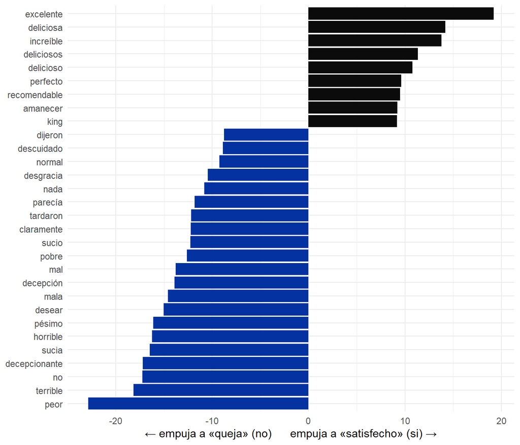

```r
coeficientes |>
  slice_max(abs(estimate), n = 30) |>
  ggplot(aes(estimate, fct_reorder(token, estimate), fill = estimate > 0)) +
  geom_col(show.legend = FALSE) +
  scale_fill_manual(values = c("#0432a1", "#0b0b0b")) +
  labs(x = "← empuja a «queja» (no)      empuja a «satisfecho» (si) →", y = NULL) +
  theme_minimal()
```

> Ojo con el signo: aquí glmnet modela la probabilidad del **segundo** nivel, `"si"`. Un coeficiente negativo empuja hacia la queja.

# Lo que me llevo

- `step_tokenize()` → (`step_stopwords()`, `step_stem()`, `step_ngram()`) → `step_tokenfilter()` → `step_tf()` / `step_tfidf()`. El orden importa.
- El vocabulario y el idf se aprenden en `prep()`, solo con los datos de entrenamiento de cada pliegue. Es la fuga que en `02_modelo.qmd` había que cuidar a mano.
- Para sentimiento, **no quites stopwords a ciegas**: pruébalo. Aquí «no» terminó siendo de las palabras que más pesan hacia la queja.
- Si el mejor valor de un hiperparámetro cae en el borde de la rejilla, amplía el rango antes de concluir.
- Texto = muchas columnas dispersas: lasso o ridge con glmnet y *blueprint* disperso.